# Methodology

## Authors

- Shane Grogan - 15383996
- James Carron - 15333196

## Introduction

This Assignment was to collect a dataset from one or more open web API's and to process and analyse the data.

We used two different APIs to obtain data, namely a Newspaper API obviously called NewsAPI (https://newsapi.org/) and the Elsevier Research API

Our overarching goal was to compare the difference in readability levels between research papers and newspapers. And to compare between subsets, namely broadsheet vs tabloid and science research papers vs arts research papers.

We also included some analysis on individual authors to see if there was any correlation between different paper metrics, ie number of citations, age of paper, type of paper, readability of paper. This should have been possible directly with the Elsevier API as well as being able to pull papers from particular institutions however this functionality seems to be broken. Until this was fixed we had to manually access each authors academic profile on Elsevier using their scopus ID and download a CSV of their publications. This was then processed to pull paper ID's and Elsevier API was used to pull the paper details.

Upon inspection it was realised using a web scraper such as Beautiful Soup to download the Author CSV was not possible as Elsevier employs a massive amount of embedded Javascript to prevent people doing this. One way to automate this would have been to use a web driver interface such as Selenium which employs a full internet browser and can emulate button clicks etc. However this was deemed outside the scope for this project.

## Process

Tackling this as a team we split the project into two parts the NewsAPI and the Research Paper API.

To make the process more clear we seperated the process into four steps

- Collect the data: pull the information from the API's, basic preprocessing was performed to reduce the overall size of the data.
- Clean the data: remove irrelevant or incomplete data that may skew the results. Also setup the data in a structure that it would be easy to analyse
- Analyse the data: create any new metrics for quantifying what we want to analyse, ie readabiliy, age etc
- Visualise the data: take the analysed data and display it in a human readable format and derive conclusions from what we observe.

## Note:

We have formatted this document to use the jupyter notebook table of contents extension to make navigating it and understanding its layout a lot easier. You can download and install it following the instructions here: https://github.com/ipython-contrib/jupyter_contrib_nbextensions and enable the table of contents extension in the setup page.

This will make it a lot easier to read and there are a lot of other nice goodies in there too

All of the code in this document we have written ourselves bar a line here and there pulled from stack overflow etc. The imported functions in Readability_functions.py are not our work and the authors are referenced in the file itself.

# Dependencies and Setup

```python
#pip install newsapi-python
from newsapi import NewsApiClient
newsapi = NewsApiClient(api_key='272b82b9b7d04617a1ed1c056279482d')

#pip install elsapy
from elsapy.elsclient import ElsClient
from elsapy.elsprofile import ElsAuthor
from elsapy.elsdoc import AbsDoc
from elsapy.elssearch import ElsSearch
# Initialize client with "apikey": "591182414737da577c81776f8c4d1842",
client = ElsClient("591182414737da577c81776f8c4d1842")


#to perform text analytics

# pip install nltk
# Please use the NLTK Downloader to obtain the resource:
#import nltk
#nltk.download('cmudict')
#nltk.download('punkt')
from nltk.corpus import cmudict
NLTK_Cmudict = cmudict.dict()
import nltk.data

import re

import sys
from io import StringIO

import pandas as pd #for database
import numpy as np

import multiprocessing #for speeding up data collection
import functools #needed for passing additional parameters to the map function

from IPython.display import display, Math, Latex  # allow latex output from Python

#for plotting graphs
import matplotlib as mpl
import matplotlib.pyplot as plt
mpl.rcParams['figure.figsize'] = (6, 6)
mpl.style.use("default")
# mpl.style.use("ggplot")
%matplotlib inline
import pylab as pl #for modifying plots made by pandas

#for statistical analysis
# !pip install seaborn
import seaborn as sns
# !pip install scipy
from scipy import stats

#Readability Functions
from Readability_functions import *
```

# Collect Data

Pull the information from the API's, basic preprocessing was performed to reduce the overall size of the data.

## Research Paper Data

While collecting the data we decided to only use the abstracts of the papers as the data in the paper body included all the formatting for the paper such as tables, figures etc. Hence we will assume the abstract is indicative of the rest of the paper.

To compare different faculties it was not actually possible to search by category defined by the author. Instead we used the categories defined by science direct as searchterms.

Note: the collect data steps of this assignment have been commented out as it takes a long time to collect all the data. JSON files are provided that will load in the data for the Clean Data stage. The collect data stage takes about an hour to pull 5000 search results for each searchterm and then pull 1000 papers details from each searchterm once multiprocessing was implemented

### Searchterms

Categories as defined by science direct

- Agricultural and Biological Sciences
- Arts and Humanities
- Biochemistry, Genetics and Molecular Biology
- Business, Management and Accounting
- Chemical Engineering
- Chemistry
- Computer Science
- Decision Sciences
- Dentistry
- Earth and Planetary Sciences
- Economics, Econometrics and Finance
- Energy
- Engineering
- Environmental Science
- Health Professions
- Immunology and Microbiology
- Materials Science
- Mathematics
- Medicine
- Neuroscience
- Nursing
- Pharmacology, Toxicology and Pharmaceutics
- Physics and Astronomy
- Psychology
- Social Sciences
- Veterinary
- Multidisciplinary

### Run the Search

#### getSearchResultsEls()

```python
def getSearchResultsEls(searchterm, OUTPUT=True):
    '''Takes a searchterm as a string and queries the scopus database
    returns a list of tuples of the form (list of results(dict), searchterm)'''

    if OUTPUT:
        print("Starting search for: {}".format(searchterm,))

    ## Initialize doc search object and execute search, retrieving all results
    doc_srch = ElsSearch(searchterm,'scopus')
    doc_srch.execute(client, get_all = True)

    if OUTPUT:
        print("Successfully searched for: {}, found {} results".format(searchterm, len(doc_srch.results)))

    return doc_srch.results, searchterm
```

Runs all the searches in parallel. IO is limited by server response time, hence we request all the searchresults at the same time

```python
# Version = "Full_V2"
# #searchterms = ['star+trek+vs+star+wars']

# search_results = list()

# pool = multiprocessing.Pool(processes = len(searchterms))
# search_results = pool.map(getSearchResultsEls, searchterms)
# pool.close()
```

This returns a huge amount of data, the search query returns 5000 results per query

### Pull Paper details from Scopus

```python
# num_papers = 1000
# data = pd.DataFrame()

# for search, searchterm in search_results:
#     print('-'*5, searchterm.upper(), '-'*5)
#     pool = multiprocessing.Pool(processes = 50)
#     func = functools.partial(readSearchResult, searchterm, OUTPUT = False)
#     parsed_results = pool.map(func, search[:num_papers])
#     pool.close()

#     data = data.append(parsed_results, ignore_index=True)

# Version = 'V3_1000'
# fname = "RESULTS/parsed_papers_results_{}.json".format(Version)
# print("Saving parsed_results to: \"{}\"".format(fname))
# data.to_json(fname)
# print("DONE")
```

#### readSearchResult( )

```python
def readSearchResult(searchterm, result, silent=True): #function which is passed to map
    '''Extracts paper id from search result, queries scopus for paper details using paper id,
    outputs a dataframe with the columns: 'searchterm', 'title', 'abstract' '''

    scopus_id = result['link'][0]['@href'][-11:] #specific place scopus id is stored in result\

    try:
        docDetails = pullDocDetails(scopus_id) #returns a dict for the result
        docDetails['searchterm'] = searchterm #add column
        if not silent:
            if len(docDetails['title'])>80:
                print("Successfully read: {}...".format(docDetails['title'][:80]))
            else:
                print("Successfully read: {}".format(docDetails['title']))
        return docDetails

    except TypeError as e:
        print("Error: {}".format(e))
        return dict()
```

#### pullDocDetails()

Pull Paper Data by Scopus_id using the Elsevier API and extract the specific info we want

```python
def pullDocDetails(scopus_id, silent = True):

    if type(scopus_id) != str:
        scopus_id = str(scopus_id)

    scp_doc = AbsDoc(scp_id = scopus_id)

    if not scp_doc.read(client):
        raise TypeError("Scopus returned no data for this Document Id")

    doc = dict()
    doc['title']    = scp_doc.data['item']['bibrecord']['head']['citation-title']
    doc['abstract'] = scp_doc.data['item']['bibrecord']['head']['abstracts']

    return doc
```

#### Implementing Multiprocessing

Testing was carried out on the searchterms = ['star+trek+vs+star+wars']; with approx 200 results, to find the optimal amount of processes.

Sending lots of requests to the server at a time resulted in more documents being returned as None. This may be because the server is refusing to serve us results as we are bombarding it. This may also be giving us false results for the higher process counts as these None entries return faster. Hence there was a trade off between speed and accuracy.

- 16min 10s w/ no multiprocessing
- 1min 45s w/ 20 processes
- 1min 49s w/ 50 processes
- 1min 17s w/ 100 processes, lots of data returned as None
- 1min 3s w/ 150 processes, lots of data returned as None
- 1min 5s w/ 200 processes, lots of data returned as None

A happy medium is around 50 processes. Running this on the larger data set returned approximately 5 None results per 1000 papers.

### Save Paper Results dataframe out as JSON

```python
# Version = 'V3_1000'
# fname = "RESULTS/parsed_papers_results_{}.json".format(Version)
# print("Saving parsed_results to: \"{}\"".format(fname))
# data.to_json(fname)
# print("DONE")
```

## News Data

### pullArticles()

Function to pull articles using the NewsAPI

```python
def pullArticles(sources, numberOfPages):

    #check if user inputted integer for number of pages
    if isinstance(numberOfPages, int):
        num_pages = numberOfPages
    else:
        print("Invalid Number of Pages, please enter an integer amount")
        return

    #iterate through list of sources specified by the user
    for source, source_info in sources.items():
        print("Attempting to pull from '{}', info: {} ".format(source,source_info))
        articles[source] = list()

        #pull data from NewsAPI
        for page in range(num_pages):
            #print("Page: {}, ".format(page+1), end="")
            data = newsapi.get_everything(q='',
                                          sources=source,
                                          domains=source_info['domain'],
                                          language=source_info['language'],
                                          page=page+1)
            if data['status'] == 'ok':
                #print("Success")
                articles[source].extend(data['articles'])
            else:
                print("Error, discarding pulled data")

    return articles
```

### Our Data Structures

'sources' is a dictionary with keys and values specified by the user

The structure of 'sources' is shown below

```python
#sources = {'the-irish-times': {'domain':'irishtimes.com', 'language':'en', "name":"The Irish Times"},
#           'rte': {'domain':'rte.ie/news', 'language':'en', "name":"RTE"},
#           'the-new-york-times': {'domain':'nytimes.com', 'language':'en', "name":"The New York Times"},
#           'daily-mail': {'domain':'dailymail.co.uk/home', 'language':'en', "name":"Daily Mail"},
#           'reddit-r-all': {'domain':'reddit.com/r/all', 'language':'en', "name":"Reddit"},
#           'le-monde': {'domain':'lemonde.fr', 'language':'fr', "name":"Le Monde"},
#           'der-tagesspiegel': {'domain':'tagesspiegel.de', 'language':'de', "name":"Der Tagesspiegel"},
#           'espn': {'domain':'espn.com', 'language':'en', "name":"ESPN"},
#           'techcrunch': {'domain':'techcrunch.com', 'language':'en', "name":"Tech Crunch"}
#          }
```

'articles' - a new dictionary item called articles

The keys for 'articles' are the sources specified by the user:

- 'the-irish-times'
- 'rte'
- 'the-new-york-times'
- 'daily-mail'
- 'reddit-r-all'
- 'le-monde'
- 'der-taggesspiegel'
- 'espn'
- 'techcrunch'

```python
#articles = {'the-irish-times': [],
#            'rte': [],
#            'the-new-york-times': [],
#            'daily-mail': [],
#            'reddit-r-all': [],
#            'le-monde': [],
#            'der-tagesspiegel': [],
#            'espn': [],
#            'techcrunch': []
#            }
```

The corresponding value for each key in 'articles' is another list of dictionaries

Each of these dictionaries gives information about one individual article.

An example of the information stored for each article is given below:

- "author": "Amy Guthrie",
- "title": "Anarchy, Bitcoin, and Murder in Acapulco",
- "description": "The once-thriving resort city of in Mexico has become a somewhat lawless place. It is, in many ways, a perfect yet imperfect place for crypto-loving anarchists to gather each year.",
- "url": "https://www.wired.com/story/anarchy-bitcoin-and-murder-in-mexico/",
- "urlToImage": "https://media.wired.com/photos/5c78615d43416573f9b95f07/191:100/pass/anarchy-in-acapulco_topart_red.jpg",
- "publishedAt": "2019-03-01T12:00:00Z",
- "content": "Its approaching midnight as hundreds of anarchists gather at the edge of the surf at a beach in Acapulco, Mexico. Monica Vallarino urges the crowd to part in half. Shes holding dozens of Gulf sea turtle hatchlings in a plastic bowl. Its time to release them t… [+17491 chars]"

Only 274 characters of the content are available to us for the free API

### Function to save articles to JSON object

```python
def saveArticles(articles,fname):

    fout = open(fname, "w")
    fout.write(json.dumps(articles))
    fout.close()
    print('Save to: {}, Successful'.format(fname))

def loadArticles(fname):

    fin = open(fname,"r")
    s = fin.read()
    fin.close()
    articles = json.loads(s)
    print('Read from: {}, Successful'.format(fname))
    return articles
```

```python
sources = {'the-irish-times': {'domain':'irishtimes.com', 'language':'en', "name":"The Irish Times"},
           'rte': {'domain':'rte.ie/news', 'language':'en', "name":"RTE"},
           'the-new-york-times': {'domain':'nytimes.com', 'language':'en', "name":"The New York Times"},
           'daily-mail': {'domain':'dailymail.co.uk/home', 'language':'en', "name":"Daily Mail"},
           'reddit-r-all': {'domain':'reddit.com/r/all', 'language':'en', "name":"Reddit"},
           'le-monde': {'domain':'lemonde.fr', 'language':'fr', "name":"Le Monde"},
           'der-tagesspiegel': {'domain':'tagesspiegel.de', 'language':'de', "name":"Der Tagesspiegel"},
           'espn': {'domain':'espn.com', 'language':'en', "name":"ESPN"},
           'techcrunch': {'domain':'techcrunch.com', 'language':'en', "name":"Tech Crunch"}
          }
fname = "Data/New-Articles.json"

# Commented to save time for examiner
#articles = pullArticles(sources, 15)
#saveArticles(articles, fname)
articles = loadArticles(fname)
```

[output not shown]

# Cleaning Data

### pretty_value_counts()

Prettifies the output of value_counts()

```python
def pretty_value_counts(data, key):
    vals = data[key].value_counts()

    print('-'*5, key.upper(), '-'*5)
    print("Value: \tCount:")
    print("-"*15)

    for val, count in vals.items():
        if type(val)==str and len(val)>40:
            print("{}... \t{}".format(val[:40], count))
        else:
            print(val, count, sep="\t")

    print("NaN: \t{}".format(len(data)-vals.sum()))
    print("-"*15)

    return
```

## Research Paper Data

### Scopus Search

```python
Version = 'V3_1000'
fname = "Data/parsed_papers_results_{}.json".format(Version)

print("Loading search_data from: \"{}\"".format(fname))
search_data = pd.read_json(fname)

num_searchterms = len(search_data['searchterm'].value_counts())
print("Loaded {:,} papers from {} different searchterms".format(len(search_data), num_searchterms))
```

```
Loading search_data from: "Data/parsed_papers_results_V3_1000.json"
Loaded 31,000 papers from 31 different searchterms
```

```python
search_data.keys()
```

```
Index(['abstract', 'searchterm', 'title'], dtype='object')
```

The data retrieved from the Scopus Paper download has the following headings

- Searchterm: string entered into the scopus search engine where the paper was found
- Title: Title of the publication itself
- Abstract: Overview of the publication

```python
search_data.head()
```

|  | abstract | searchterm | title |
| --- | --- | --- | --- |
| 0 | © Springer Nature Switzerland AG 2020. The pap... | Agriculture | Universal Data Acquisition Module PIAP-UDAM fo... |
| 1 | © Springer Nature Switzerland AG 2020. An acti... | Agriculture | Digital farming development in Russia: Regiona... |
| 10 | © 2018 Wiley Periodicals, Inc. Members’ offlin... | Agriculture | Can members’ WeChat engagement affect relation... |
| 100 | © 2019, The Author(s). This study aimed to det... | Agriculture | Comparative fatty-acid profile and atherogenic... |
| 1000 | © Springer Nature Switzerland AG 2020. Biologi... | Biology | Automatic Control and Feedback Loops in Biolog... |

```python
pretty_value_counts(search_data, 'searchterm')
```

```
----- SEARCHTERM -----
Value: 	Count:
---------------
Pharmacology	1000
Astronomy	1000
Veterinary	1000
Humanities	1000
Physics	1000
Psychology	999
Nursing	999
Quantum	999
Neuroscience	999
Material	998
Social Sciences	998
Environment	998
Biology	997
Agriculture	997
Art	996
Finance	996
Medicine	996
Business	996
Chemistry	996
Math	996
Genetics	995
Engineering	995
Compute	995
Health	995
Management	995
Energy	994
Economics	994
Dentist	993
Science	993
Earth	993
Accounting	989
NaN: 	109
---------------
```

Removing the entries with no information which resulted from scopus not returning any data

```python
len_before = len(search_data)
search_data.dropna(how='all',inplace=True) #remove a row if any of the entries contain NaN
print("{} NaNs removed".format(len_before-len(search_data)))
```

```
109 NaNs removed
```

A massive amount of the papers pulled are duplicates and hence will skew the data if they are not filtered out.

```python
# pretty_value_counts(search_data, 'abstract')
```

```python
#Remove duplicate entries in the data set
len_before = len(search_data)
search_data.drop_duplicates(subset='abstract', keep='first', inplace=True)
print("{} Duplicates removed".format(len_before-len(search_data)))
```

```
14687 Duplicates removed
```

Looking at the remaining data we find there are search terms with very few remaining results, hence the sample size may be too small and outliers will have a significant effect. I will remove searchterms with less then 100 results.

```python
pretty_value_counts(search_data, 'searchterm')
search_data = search_data.groupby(by='searchterm').filter(lambda search_group: len(search_group) > 100)
```

```
----- SEARCHTERM -----
Value: 	Count:
---------------
Compute	994
Dentist	919
Science	916
Humanities	872
Nursing	825
Economics	819
Biology	813
Astronomy	800
Earth	774
Math	754
Finance	750
Veterinary	732
Energy	612
Health	566
Agriculture	536
Accounting	534
Neuroscience	484
Medicine	447
Art	430
Engineering	409
Environment	350
Psychology	279
Pharmacology	277
Quantum	275
Business	226
Material	207
Genetics	191
Physics	169
Chemistry	97
Management	81
Social Sciences	66
NaN: 	0
---------------
```

```python
print('{} documents remaining'.format(len(search_data)))
```

```
15960 documents remaining
```

## Scopus Author Data

```python
fname = "Data/JTS_scopus.csv"

author = 'John T. Sheridan'
print("Loading author_data from: \"{}\"".format(fname))
author_data = pd.read_csv(fname)
author_data['Author'] = author
print("{} contributed to {} publications".format(author, len(author_data)))
```

```
Loading author_data from: "Data/JTS_scopus.csv"
John T. Sheridan contributed to 421 publications
```

```python
author_data.keys()
```

```
Index(['Authors', 'Author(s) ID', 'Title', 'Year', 'Source title', 'Volume',
       'Issue', 'Art. No.', 'Page start', 'Page end', 'Page count', 'Cited by',
       'DOI', 'Link', 'Abstract', 'Document Type', 'Publication Stage',
       'Access Type', 'Source', 'EID', 'Author'],
      dtype='object')
```

The data retrieved from the Scopus Author download has the following headings

- Authors, Author ID, Author Initials: Names, Scopus ID's and initials of the people who contributed to the publication
- Title: Title of the publication itself
- Year: Year publication was accepted.
- Source title, Volume, Issue, Art. No., Page start, Page end: Where the paper was published
- Page count: Length of the publication
- Cited by: Number of times this publication has been referred to by other publications
- DOI, EID:
- Link:
- Abstract: Overview of the publication
- Document Type: Format of the publication
- Publication Stage: Is the publication a draft or final
- Access Type: Is the publication free or pay to access
- Source: Where has the publication been pulled from

```python
author_data.head()
```

|  | Authors | Author(s) ID | Title | Year | Source title | Volume | Issue | Art. No. | Page start | Page end | ... | Cited by | DOI | Link | Abstract | Document Type | Publication Stage | Access Type | Source | EID | Author |
| --- | --- | --- | --- | --- | --- | --- | --- | --- | --- | --- | --- | --- | --- | --- | --- | --- | --- | --- | --- | --- | --- |
| 0 | Kumar R., Sheridan J.T., Bhaduri B. | 55492127000;7201682655;13605935500; | Nonlinear double image encryption using 2D non... | 2018 | Optics and Laser Technology | 107 | NaN | NaN | 353 | 360 | ... | 2.0 | 10.1016/j.optlastec.2018.06.014 | https://www.scopus.com/inward/record.uri?eid=2... | In this paper, we propose a new asymmetric met... | Article | Final | NaN | Scopus | 2-s2.0-85048324215 | John T. Sheridan |
| 1 | Louise Bradley A., Leahy M., Riza N.A., Sherid... | 57203320151;7101611631;7103231658;7201682655; | Optics in Ireland: introduction to the feature... | 2018 | Applied Optics | 57 | 22 | NaN | IRE1 | NaN | ... | NaN | 10.1364/AO.57.00IRE1 | https://www.scopus.com/inward/record.uri?eid=2... | This feature issue provides a snapshot of some... | Review | Final | NaN | Scopus | 2-s2.0-85051243187 | John T. Sheridan |
| 2 | Li H., Qi Y., Guo C., Malallah R., Sheridan J.T. | 55804706800;55303649500;55782336900;5689384090... | Holographic characterization of diffraction gr... | 2018 | Applied Optics | 57 | 22 | NaN | E107 | E117 | ... | 1.0 | 10.1364/AO.57.00E107 | https://www.scopus.com/inward/record.uri?eid=2... | In general, the holographic grating refractive... | Article | Final | NaN | Scopus | 2-s2.0-85051272123 | John T. Sheridan |
| 3 | Malallah R., Cassidy D., Muniraj I., Ryle J.P.... | 56893840900;57193832967;55549099300;1405697940... | Self-written waveguides in photopolymer | 2018 | Applied Optics | 57 | 22 | NaN | E80 | E88 | ... | 3.0 | 10.1364/AO.57.000E80 | https://www.scopus.com/inward/record.uri?eid=2... | Self-written waveguide (SWW) trajectories fabr... | Article | Final | NaN | Scopus | 2-s2.0-85051273473 | John T. Sheridan |
| 4 | Guo C., Li D., Kelly D.P., Li H., Ryle J.P., S... | 55782336900;36521412000;56044455800;5580470680... | Measuring refractive index of glass by using s... | 2018 | Applied Optics | 57 | 22 | NaN | E205 | E217 | ... | 1.0 | 10.1364/AO.57.00E205 | https://www.scopus.com/inward/record.uri?eid=2... | A method to measure the refractive index of an... | Article | Final | NaN | Scopus | 2-s2.0-85051272193 | John T. Sheridan |

5 rows × 21 columns

We can get a feel for the contents of the dataframe by calling the value_counts() method on it. Here I have put in a wrapper to make interpreting the data easier

```python
pretty_value_counts(author_data, 'Page count')
pretty_value_counts(author_data, 'Source')
pretty_value_counts(author_data, 'Document Type')
pretty_value_counts(author_data, 'Publication Stage')
pretty_value_counts(author_data, 'Access Type')
# pretty_value_counts(author_data, 'Cited by')
```

[output not shown]

### Remove unneccessary info

Most of the data pulled will not be useful to use, hence we will remove this to make the dataframe smaller and hence easier to process

```python
keep_columns = ['Authors', 'Author', 'Title', 'Year', 'Source title', 'Cited by',
       'Link', 'Abstract', 'Document Type']

all_columns = author_data.keys()

for column in all_columns: #remove all the columns we don't want
    if column not in keep_columns:
        del author_data[column]
```

When an abstract was not available for the paper a string containing '[No abstract available]' was returned, these must be filtered out

```python
author_data = author_data[author_data['Abstract'] != '[No abstract available]']
```

Papers are sometimes republished with slight modifications to the main body. These we consider to be duplicates and can be detected as having the same abstract. We filter them out so they do not skew the results.

```python
# pretty_value_counts(author_data, 'Abstract')
```

```python
#Remove duplicate entries in the data set
len_before = len(author_data)
author_data.drop_duplicates(subset='Abstract', keep='first', inplace=True)
print("{} Duplicates removed".format(len_before-len(author_data)))
```

```
12 Duplicates removed
```

Some of the papers had NaN values for the 'Cited by', this was assumed to indicate the document was not cited as there were no papers with 0 citations.

```python
author_data['Cited by'].fillna(0, inplace=True) #replace any NaN values with 0
```

```python
author_data.head()
```

|  | Authors | Title | Year | Source title | Cited by | Link | Abstract | Document Type | Author |
| --- | --- | --- | --- | --- | --- | --- | --- | --- | --- |
| 0 | Kumar R., Sheridan J.T., Bhaduri B. | Nonlinear double image encryption using 2D non... | 2018 | Optics and Laser Technology | 2.0 | https://www.scopus.com/inward/record.uri?eid=2... | In this paper, we propose a new asymmetric met... | Article | John T. Sheridan |
| 1 | Louise Bradley A., Leahy M., Riza N.A., Sherid... | Optics in Ireland: introduction to the feature... | 2018 | Applied Optics | 0.0 | https://www.scopus.com/inward/record.uri?eid=2... | This feature issue provides a snapshot of some... | Review | John T. Sheridan |
| 2 | Li H., Qi Y., Guo C., Malallah R., Sheridan J.T. | Holographic characterization of diffraction gr... | 2018 | Applied Optics | 1.0 | https://www.scopus.com/inward/record.uri?eid=2... | In general, the holographic grating refractive... | Article | John T. Sheridan |
| 3 | Malallah R., Cassidy D., Muniraj I., Ryle J.P.... | Self-written waveguides in photopolymer | 2018 | Applied Optics | 3.0 | https://www.scopus.com/inward/record.uri?eid=2... | Self-written waveguide (SWW) trajectories fabr... | Article | John T. Sheridan |
| 4 | Guo C., Li D., Kelly D.P., Li H., Ryle J.P., S... | Measuring refractive index of glass by using s... | 2018 | Applied Optics | 1.0 | https://www.scopus.com/inward/record.uri?eid=2... | A method to measure the refractive index of an... | Article | John T. Sheridan |

## News Data

First we need to convert the content from a string to a list of words, so that we can perform our analysis.

We must also remove the final sentence of the content because of the presence of the [+1210 chars].

### Convert to Data Frames

```python
def convertToDF(sources, articles):
    totalSource = []
    totalScore = []

    #iterate through sources
    for source, source_info in sources.items():
        listSource = []
        listScore = []

        #iterate through articles in each source, and add their Read Score to a list
        for count in range(len(articles[source])):
            x = source_info["name"]
            y = articles[source][count]["Read Score"]
            listSource.append(x)
            listScore.append(y)

        setScore = set(listScore)
        listScore = list(setScore) #removed duplicate values
        listSource = listSource[0:len(listScore)] #makes list of sources the same length as list of scores

        totalSource.extend(listSource)
        totalScore.extend(listScore)

    #create large data frame with all sources and scores
    ReadabilityScores = pd.DataFrame({"Source":totalSource,
                                      "Score":totalScore
                                     })
    #remove any zero values
    ReadabilityScores = ReadabilityScores[ReadabilityScores['Score'] != 0.0]

    return ReadabilityScores

#convertToDF(sources, articles)
```

### Seperate into Different Newspapers

```python
def seperateDFs(articles, sources):

    #group the big df by Source
    grouped = ReadabilityScores.groupby("Source")

    #create dictionary key = source , value = data frame for that source
    dictionaryDF = {}

    #iterate through sources and create an individual data frame for each
    for source, source_info in sources.items():
        dictionaryDF[source_info["name"]] = grouped.get_group(source_info["name"])

    #return dictionary, individual data frames can be accessed by dictionaryDF["The Irish Times"] etc.
    return dictionaryDF

#seperateDFs(articles, sources)
```

Some more cleaning of the data is conducted after the text analysis is performed.

# Analysis

## Readability Test

The majority of our analysis will be based on Readability which is quantified using the Flesch reading-ease test. The Flesch readability tests are designed to indicate how difficult a passage in English is to understand. This test rates text on a 100-point scale. The higher the score, the easier it is to understand the document. For most standard files, you want the score to be between 60 and 70.

The formula for the Flesch reading-ease score (FRES) test is:

\begin{align} =& 206.835 - 1.015 \left( \text{ASL} \right) - 84.6 \left( \text{ASW} \right) \\ =& 206.835 - 1.015 \left( \frac{\text{total words}} {\text{total sentences}} \right) - 84.6 \left( \frac{\text{total syllables}} {\text{total words}} \right) \end{align}

where:

- ASL = average sentence length (the number of words divided by the number of sentences)
- ASW = average number of syllables per word (the number of syllables divided by the number of words)

| Score | Notes |
| --- | --- |
| 90-100 | Very easy to read. Easily understood by an average 11-year-old student. |
| 80-90 | Easy to read. Conversational English for consumers. |
| 70-80 | Fairly easy to read. |
| 60-70 | Plain English. Easily understood by 13- to 15-year-old students. |
| 50-60 | Fairly difficult to read. |
| 30-50 | Difficult to read. |
| 0-30 | Very difficult to read. Best understood by university graduates. |

For our analysis we assume that the abstract of the document is indicative of its overall complexity.

### fleschScore()

Employs the flesch score test and returns a float value quantifying its readability and a NaN value if an error occurs

```python
def fleschScore(text, ret_errors = False, OUTPUT = False):
    if text == None :
        return np.NaN

    text_parsed = parseText(text, NewsAPI=True, OUTPUT = OUTPUT)

    NOSy = 0 #Number of syllables in the text
    NOW = 0 #Number of words in the text
    NOS = len(text_parsed) #Number of sentences in the text

    if NOS == 0:
        return np.NaN

    errors = 0

    for sentence in text_parsed:
        NOW += len(sentence) #Number of words in the sentence

        for word in sentence:
            try:
                NOSy += nsyl(word)

            except Exception as e:
                #print(e)
                errors += 1
                if OUTPUT:
                    print("Error processing: \"{}\"".format(word))
                try: #if word not found in cmudict use approximation
                    NOSy += syllables(word)

                except Exception as e: #if string is invalid (a number, symbol, etc)
                    print("Error counting syllables in: \"{}\"".format(word))
                    #print(e)

    ASL = NOW / NOS
    ASW = NOSy / NOW
    RS = 206.835 - (1.015 * ASL) - (84.6 * ASW)

    # if RS <= 0:
    #     return np.NaN
    # if RS >= 100:
    #     return np.NaN
    if ret_errors:
        return (RS, errors)
    if OUTPUT:
        print(RS)
    return RS
```

### parseText()

Returns a list of lists where its a list of sentences containing lists of words.

```python
def parseText(text, NewsAPI=False, OUTPUT = False):

    #split the text into sentences
    tokenizer = nltk.data.load('tokenizers/punkt/english.pickle')
    sentences = tokenizer.tokenize(text)

    #split the sentences into words
    sentences = [re.compile('\w+').findall(sentence) for sentence in sentences]

    #The last sentence of the NewsAPI text can't be used because of the presence of [+1210 chars]
    #therefore it must be removed
#     if NewsAPI: #checks if text is from NewsAPI or Academic Paper
#         if OUTPUT:
#             print("Removing: \"{}\" ".format(sentences[-1]))
#         del(sentences[-1])

    return sentences
```

## Research Paper Data

### Readability

Calculating the readability score for each document and creating a corresponding column entry

```python
search_data['readability'] = [fleschScore(paper['abstract']) for index, paper in search_data.iterrows()]

#fleschScore returns NaN values when the score cannot be computed.
len_before = len(search_data)
search_data.dropna(how='all',inplace=True)
print("{} NaNs removed".format(len_before-len(search_data)))
```

```
0 NaNs removed
```

## Scopus Author

```python
author_data['Readability'] = [fleschScore(abstract) for abstract in author_data['Abstract']]

author_data['Age'] = [2019-year for year in author_data['Year']]
```

### docType_id()

Its difficult to plot by category, hence we use a look up table to represent the categories as indices

```python
def doctype_id(doc_string):
    if doc_string == 'Article':
        return 7
    if doc_string == 'Conference Paper':
        return 6
    if doc_string == 'Review':
        return 5
    if doc_string == 'Editorial':
        return 4
    if doc_string == 'Book Chapter':
        return 3
    if doc_string == 'Note':
        return 2
    if doc_string == 'Erratum':
        return 1
    if doc_string == 'NaN: ':
        return 0

author_data['DocType Id'] = [doctype_id(doc_type) for doc_type in author_data['Document Type']]
```

## News Data

Analyse a news source and create a new column with the readability scores

```python
def assignFleschScore(sources, articles):

    #iterate through sources
    for source, source_info in sources.items():

        #iterate through articles in each source to assign each a score
        for count in range(len(articles[source])):

            #print("Checking search result no: {}, ".format(count),end="")
            test_text = articles[source][count]["content"]
            score = fleschScore(test_text)
            articles[source][count]["Read Score"] = score
            #print("{}".format(score))
    return articles
```

### Run Analysis

```python
articles = assignFleschScore(sources, articles)
ReadabilityScores = convertToDF(sources, articles)
dictionaryDF = seperateDFs(articles, sources)
```

```python
len_before = len(ReadabilityScores)
ReadabilityScores.dropna(how='any',inplace=True) #remove a row if any of the entries contain NaN
print("{} NaNs removed".format(len_before-len(ReadabilityScores)))
```

```
8 NaNs removed
```

# Visualisation

## Research Paper Data

### Scopus Search

#### Comparing readability across different faculities, including outliers

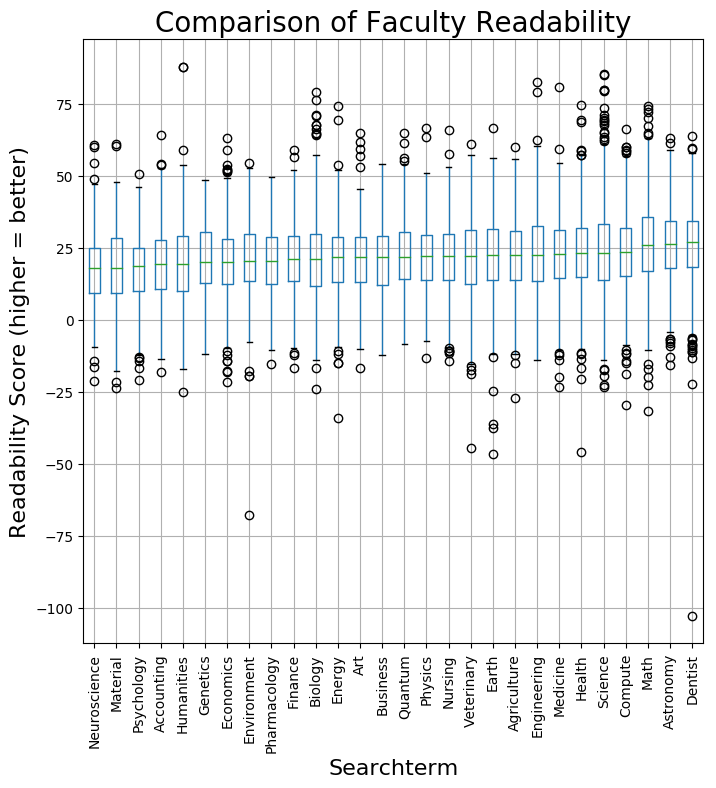

```python
grouped = pd.DataFrame({col:vals['readability'] for col, vals in search_data.groupby('searchterm')})
medians = grouped.median().sort_values() #find the median values for each searchterm so we can sort by them

fig = plt.figure(figsize=(8,8),dpi=100)
ax = plt.subplot(111)
grouped[medians.index].boxplot(rot=90,ax=ax)

plt.title('Comparison of Faculty Readability',fontsize=20)
plt.xlabel('Searchterm',fontsize=16)
plt.ylabel('Readability Score (higher = better)',fontsize=16)

plt.show()
```

#### Outliers

```python
search_data_outliers_high = search_data[search_data['readability'] > 90]
for index, paper in search_data_outliers_high.iterrows():
    print(paper['title'], paper['abstract'], end='\n\n'),
```

```python
#search_data_outliers_low = search_data[search_data['readability'] < 0]
#for index, paper in search_data_outliers_low.iterrows():
#    print(paper['title'], paper['abstract'], end='\n\n',sep='\n'),
```

```python
search_data_cleaned = search_data[search_data['readability'] > 0] #remove readability scores below 0
search_data_cleaned = search_data_cleaned[search_data_cleaned['readability'] < 100] #remove readability scores above 100
```

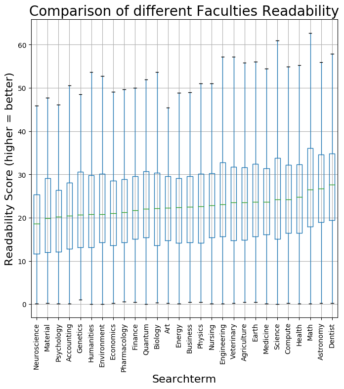

```python
grouped = pd.DataFrame({col:vals['readability'] for col, vals in search_data_cleaned.groupby('searchterm')})
medians = grouped.median().sort_values() #find the median values for each searchterm so we can sort by them

fig = plt.figure(figsize=(8,8),dpi=100)
ax = plt.subplot(111)
grouped[medians.index].boxplot(rot=90,ax=ax, showfliers=False)

plt.title('Comparison of different Faculties Readability',fontsize=20)
plt.xlabel('Searchterm',fontsize=16)
plt.ylabel('Readability Score (higher = better)',fontsize=16)

plt.show()
```

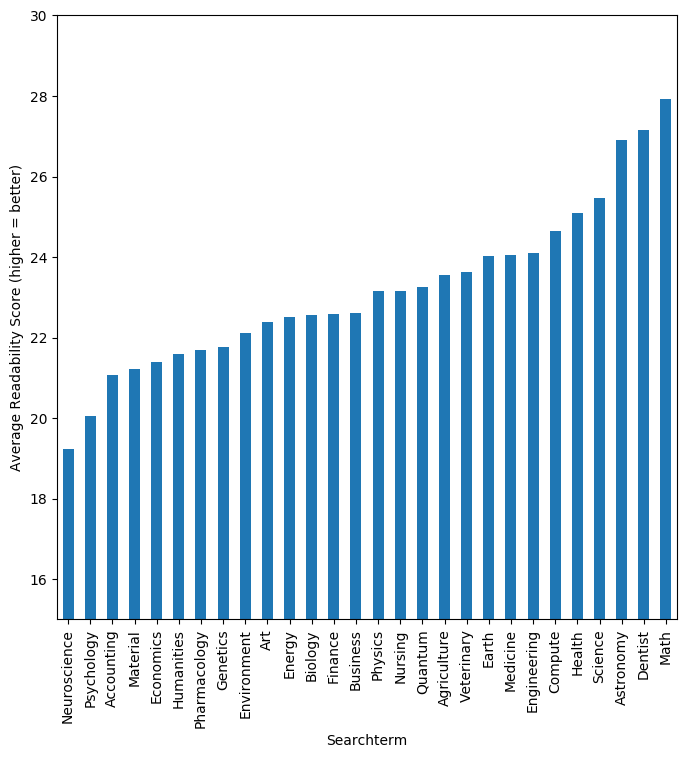

```python
group_search = search_data_cleaned.groupby('searchterm')
group_readability = group_search['readability'].agg(np.mean)
group_readability.sort_values(inplace=True)

fig = plt.figure(figsize=(8,8),dpi=100)
ax = plt.subplot(111)
group_readability.plot(kind='bar',ax=ax)
plt.xlabel('Searchterm')
plt.ylabel('Average Readability Score (higher = better)')
plt.ylim((15,30))

plt.show()
```

All of the faculties have similar readability scores. Almost all of the faculties’ median readability scores lie between 20 and 30. Interestingly the Scientific research papers ranked higher on our readability scales than most of the humanities and business research papers.

## Scopus Author

### plot_author_statsvstime()

Take an author and analyse their publications

```python
def plot_author_statsvstime(author_data, author):

    grouped_author = author_data.groupby('Author').get_group(author)
    grouped_year = grouped_author.groupby('Year')
    readability_binned = grouped_year['Readability'].agg(np.mean)
    citations_binned = grouped_year['Cited by'].agg(np.mean)


    fig = plt.figure(figsize=(18,6))

    most_cited_paper = author_data.iloc[author_data['Cited by'].idxmax()]

    host = fig.add_subplot(122) #define the main plot
    par1 = host.twinx() #add a parasite plot

    fig.suptitle('{} stats vs time'.format(author))
    host.set_xlabel("Year Published")
    host.set_ylabel("Readability")
    par1.set_ylabel("Citations")

    color1 = plt.cm.viridis(0.5)
    color2 = plt.cm.viridis(0.9)

    p1, = host.plot(readability_binned, color=color1, label="Readability")
    p2, = par1.plot(citations_binned, color=color2, label="Citations")

    lns = [p1, p2]
    host.legend(handles=lns, loc='best')

    host.autoscale(enable=True, axis='x', tight=True)
    par1.autoscale(enable=True, axis='x', tight=True)

    if fig == None:
        plt.show()
```

### pi_subplot()

```python
def pi_subplot(figure, counts, title, i, legend = False, num_x = 3, num_y = 1):

    ax = figure.add_subplot(num_y,num_x,i)

    if legend:
        counts.plot(kind='pie', ax=ax, autopct='%2.0f%%', startangle=180, fontsize=12, counterclock=False, labels=None)
        ax.legend(loc="right", labels=counts.index)

    else:
        counts.plot(kind='pie', ax=ax, autopct='%2.0f%%', startangle=180, fontsize=12, counterclock=False)

    ax.set_xlabel('')
    ax.set_ylabel('')

    ax.set_title(title, fontsize=16)
```

### Author_stats()

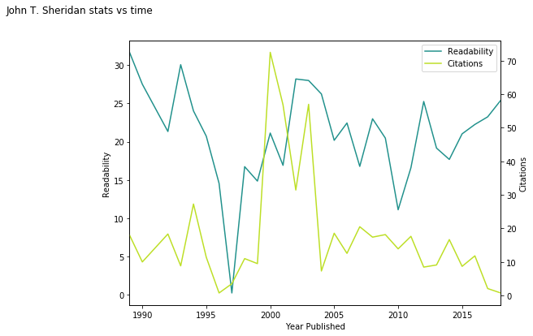

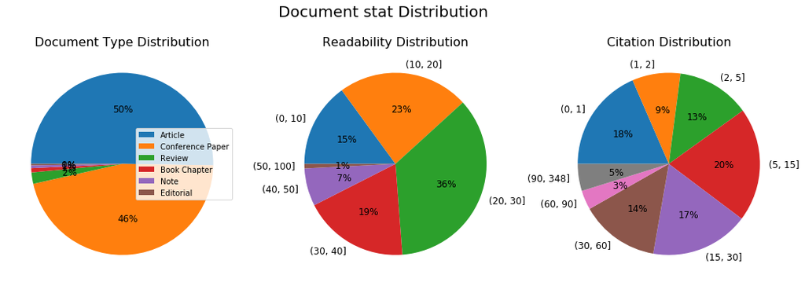

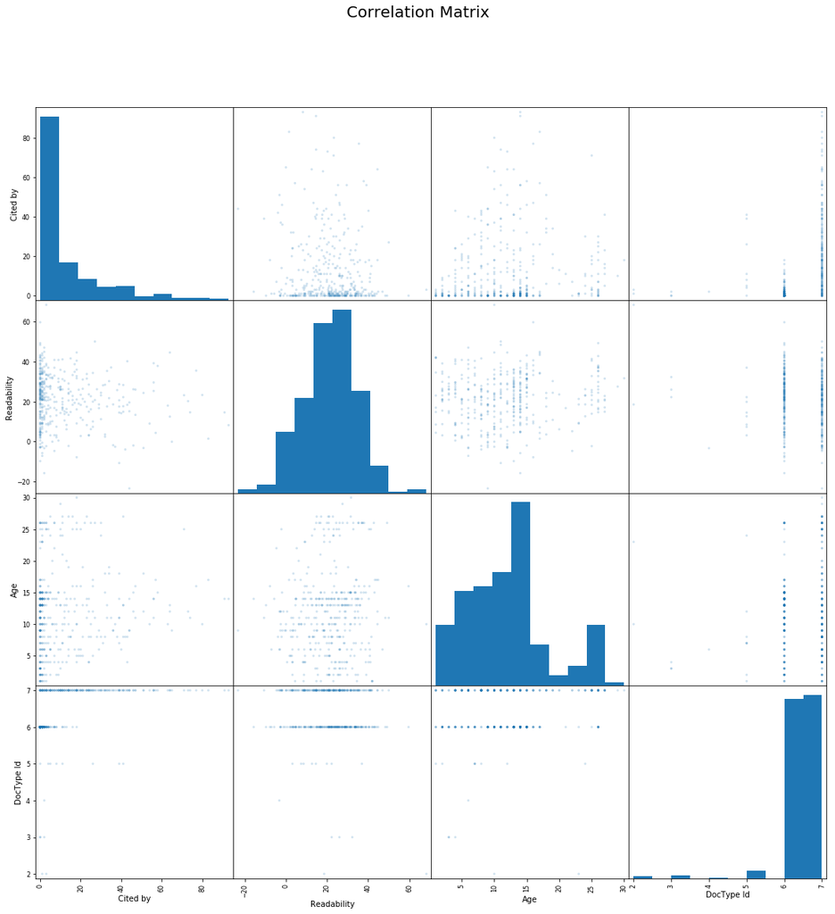

```python
def Author_stats(author_data, author):
    '''Display a bunch of stats about an author'''

    # variation of published documents type, readability and citations over time
    plot_author_statsvstime(author_data, author)

    fig = plt.figure(figsize=(18,6))
    fig.suptitle('Document stat Distribution',fontsize = 20)

    #Document Type Distribution
    doc_counts = pd.value_counts(author_data['Document Type'])
    pi_subplot(fig, doc_counts, "Document Type Distribution", 1, legend=True)

    #Readability Distribution
    bins = [i for i in np.arange(0,60,10)]+[100]

    binned = pd.cut(author_data['Readability'], bins)
    read_counts = pd.value_counts(binned)
    read_counts.sort_index(inplace=True)

    pi_subplot(fig, read_counts, "Readability Distribution", 2)

    #Citation Distribution
    bins = [0,1,2]
    bins += [i for i in range(5,25,10)]
    bins += [i for i in range(30,100,30)]
    max_val = int(author_data['Cited by'].max())
    bins += [max_val]

    binned = pd.cut(author_data['Cited by'], bins)
    citation_counts = pd.value_counts(binned)
    citation_counts.sort_index(inplace=True)

    pi_subplot(fig, citation_counts, "Citation Distribution", 3)
    plt.show()

    #Correlation Matrix
    correlation_data = author_data[['Cited by', 'Readability', 'Age', 'DocType Id']]
    correlation_data = correlation_data[author_data['Cited by'] < 100]

    axes = pd.plotting.scatter_matrix(correlation_data, alpha=0.2, figsize = (18,18))
    pl.suptitle('Correlation Matrix', fontsize = 20)

author = 'John T. Sheridan'
Author_stats(author_data, author)
```

#### Stat Distribution

The citations of John T. Sheridan’s research papers vary between 0 and 70 between the years of 1990 and 2018. There is no discernible pattern to be observed between the number of citations and the year of publishing. The one exception to this rule is that between the years 2000-2004 there was a spike in the average number of citations per research paper. This leads us to conclude that John T. Sheridan must have been completing exciting and novel research at this point.

There is no discernible correlation between average readability of articles in a year and number of citations in a year.

#### Correlation Matrix

The correlation matrix shows no clear correlations between any two sets of data available. This result was surprising. We expected that the age of the article might be correlated with the number of citations. We also expected that the readability might be correlated with the number of citations, but neither of these expectations were true.

## News Data

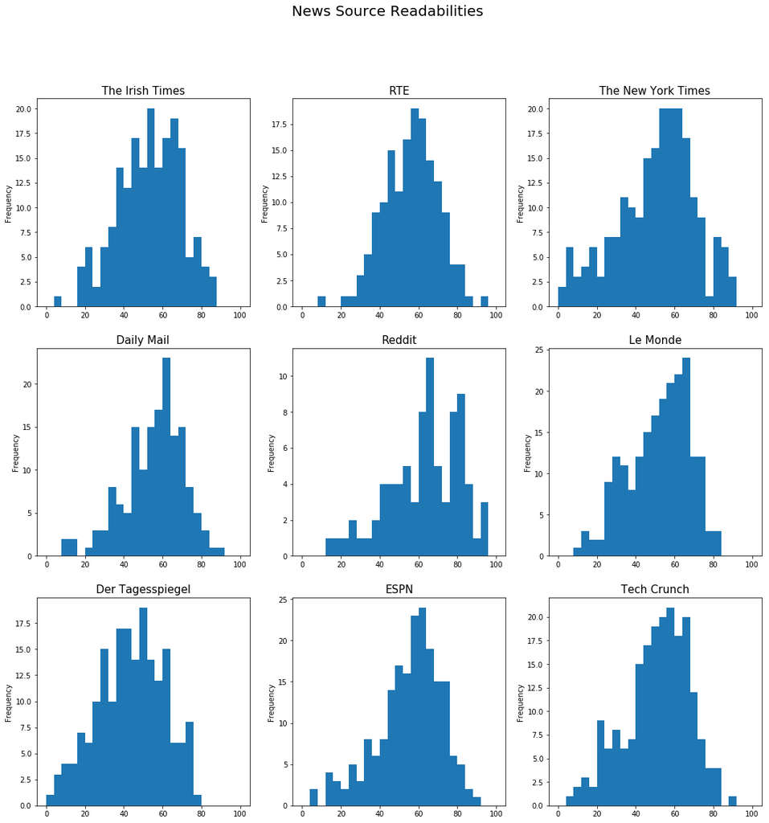

```python
#create figure
fig = plt.figure(figsize=(18,18))
fig.suptitle('News Source Readabilities',fontsize = 20)

#create increment
i = 1

#plot 9 subplots, 3 rows and 3 columns
#displaying readability distributions for each news source on a histogram
for source, source_info in sources.items():
    ax = fig.add_subplot(3,3,i)
    ax.set_title(source_info["name"], fontsize = 15)
    dictionaryDF[source_info["name"]]["Score"].plot(kind="hist", bins= np.arange(0, 101, 4), ax = ax)
    i = i + 1
```

Some differences in distribution shape are evident. However difficult to discern. We will compare two categories at a time to attempt to identify where differences lie.

### German vs French

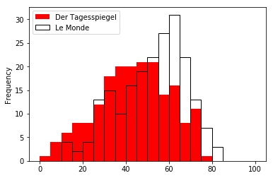

```python
dictionaryDF["Der Tagesspiegel"]["Score"].plot(kind="hist", bins= np.arange(0, 101, 5), facecolor = 'r')
dictionaryDF["Le Monde"]["Score"].plot(kind="hist", bins= np.arange(0, 101, 5), facecolor = 'None', edgecolor = 'k')
plt.legend(["Der Tagesspiegel", "Le Monde"])
```

Even though the Flesch Reading Score is only designed for the English language we thought it would be interesting to compare different languages using the score. The French newspaper is left skewed. The German newspaper is more symmetrical, however it has a higher proportion of articles with a lower readability score. This makes sense owing to the fact that nouns in German are commonly compound words, being devised of various other nouns – leading to words with many syllables.

### Irish Times vs. RTE

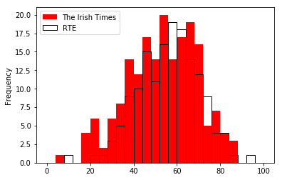

```python
dictionaryDF["The Irish Times"]["Score"].plot(kind="hist", bins= np.arange(0, 101, 4), facecolor = 'r')
dictionaryDF["RTE"]["Score"].plot(kind="hist", bins= np.arange(0, 101, 4), facecolor = 'None', edgecolor = 'k')
plt.legend(["The Irish Times", "RTE"])
```

We observed no real differences between the two news outlets.

### Irish Times vs. New York Times

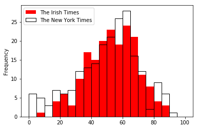

```python
dictionaryDF["The Irish Times"]["Score"].plot(kind="hist", bins= np.arange(0, 101, 5), facecolor = 'r')
dictionaryDF["The New York Times"]["Score"].plot(kind="hist", bins= np.arange(0, 101, 5), facecolor = 'None', edgecolor = 'k')
plt.legend(["The Irish Times", "The New York Times"])
```

We observed no real differences between the two news outlets.

### Broadsheet vs. Tabloid (New York Times vs. Daily Mail)

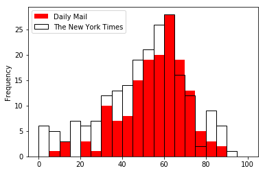

```python
dictionaryDF["Daily Mail"]["Score"].plot(kind="hist", bins= np.arange(0, 101, 5), facecolor = 'r')
dictionaryDF["The New York Times"]["Score"].plot(kind="hist", bins= np.arange(0, 101, 5), facecolor = 'None', edgecolor = 'k')
plt.legend(["Daily Mail", "The New York Times"])
```

The New York times is symmetrically distributed. The Daily Mail is slightly left skewed, with a larger proportion of higher readability scores. The New York Times also has a wider variance of readability score. The Daily Mail’s scores are less varied.

### Public created content vs. Professional Content (reddit vs. New York Times)

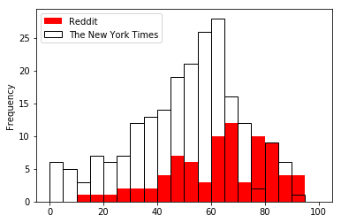

```python
dictionaryDF["Reddit"]["Score"].plot(kind="hist", bins= np.arange(0, 101, 5), facecolor = 'r')
dictionaryDF["The New York Times"]["Score"].plot(kind="hist", bins= np.arange(0, 101, 5), facecolor = 'None', edgecolor = 'k')
plt.legend(["Reddit", "The New York Times"])
```

There was not enough data collected from reddit to draw any conclusions.

### Sports News vs. Tech News (ESPN vs. Tech Crunch)

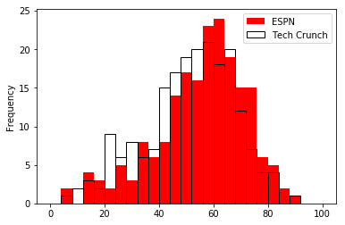

```python
dictionaryDF["ESPN"]["Score"].plot(kind="hist", bins= np.arange(0, 101, 4), facecolor = 'r')
dictionaryDF["Tech Crunch"]["Score"].plot(kind="hist", bins= np.arange(0, 101, 4), facecolor = 'None', edgecolor = 'k')
plt.legend(["ESPN", "Tech Crunch"])
```

Both news outlets’ readability scores were normally distributed. Both were very similar and there were no major differences observed. This result was somewhat surprising, we expected the Tech News outlet to have lower readability scores.

### Comparison of News Source Readability - Box Plot

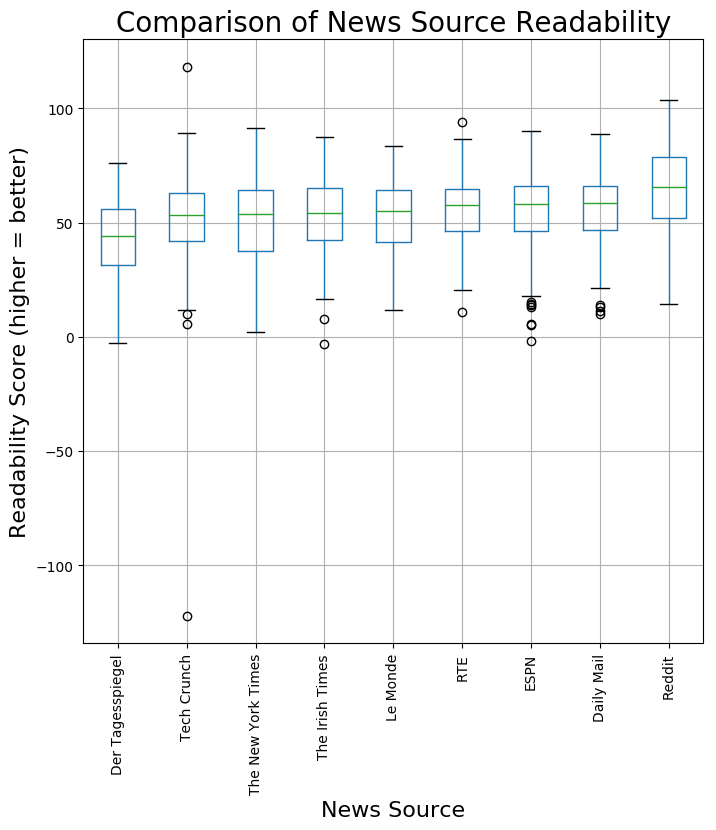

```python
grouped = pd.DataFrame({col:vals['Score'] for col, vals in ReadabilityScores.groupby('Source')})
medians = grouped.median().sort_values() #find the median values for each searchterm so we can sort by them

fig = plt.figure(figsize=(8,8),dpi=100)
ax = plt.subplot(111)

grouped[medians.index].boxplot(rot=90,ax=ax)

plt.title('Comparison of News Source Readability',fontsize=20)
plt.xlabel('News Source',fontsize=16)
plt.ylabel('Readability Score (higher = better)',fontsize=16)

plt.show()
```

### Comparison of Average News Source Readability

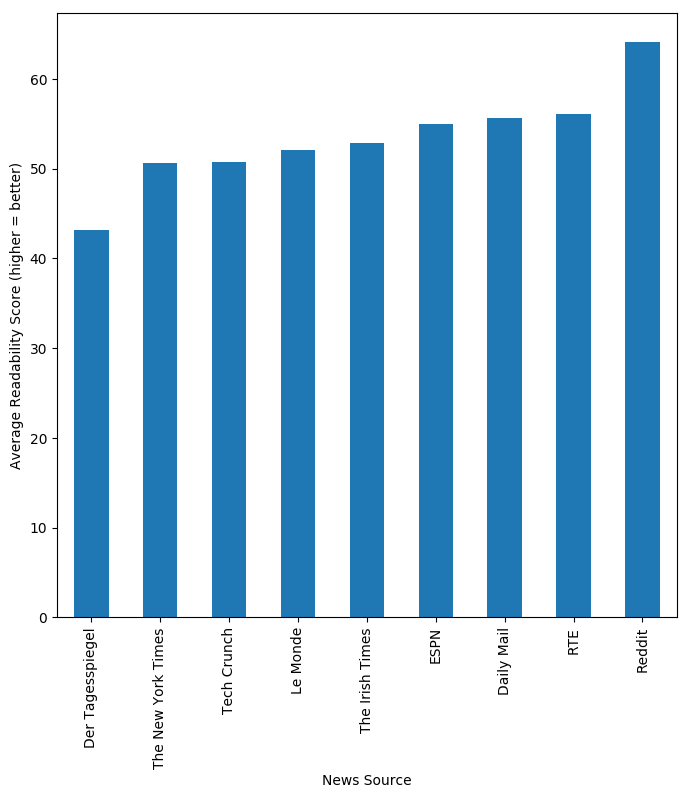

```python
group_search = ReadabilityScores.groupby('Source')
group_readability = group_search['Score'].agg(np.mean)
group_readability.sort_values(inplace=True)

fig = plt.figure(figsize=(8,8),dpi=100)
ax = plt.subplot(111)
group_readability.plot(kind='bar',ax=ax)
plt.xlabel('News Source')
plt.ylabel('Average Readability Score (higher = better)')

plt.show()
```